# 这

What to do? The consortium meeting is in three days. I stared at them all, looking for a pattern. There has to be a pattern. The first definition of thesis is a proposition advanced and maintained by argument. If there is no proposition there is no thesis. If there is no thesis there is at least no master's degree, and certainly no Ph.D. There must be something more to say about these narrow lines generated by a computer printer. What to do?

在透明胶片上追踪它们。

Trace them on transparencies.

好的，我会在透明塑料上追踪它们。怎么办？

Okay, I'll trace them on clear plastic. Now what?

用小箭头标记注射开始的位置。

Mark where the injection starts with a little arrow.

很容易。还有什么？

Easy enough. What else?

将透明胶片一张叠地堆放起来，然后将它们滑动，直到燃烧开始的陡峭部分在同一位置对齐。

Pile the transparencies one on top of the other, and slide them around until the steep part of the start of combustion lines up at the same place.

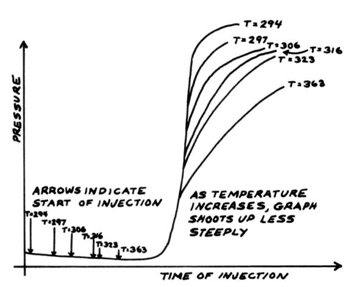

那平静的、细小的声音不在火中。

The still, small voice was not in the fire.

T+ 19,000 小时。我们有论文，休斯顿。我们有论文。任务控制中心鼓掌欢呼，工程师们互相拥抱、握手、拍拍彼此的背，抬头看着大屏幕电视，不止一双眼睛涌出泪水。鹰已着陆。

Tplus 19,000 hours. We have thesis, Houston. We have thesis. Mission Control clapped and cheered and the engineers hugged one another and shook one anothers' hands and patted one another on the back and looked up at the large-screen television and tears welled up in more than one pair of eyes. The Eagle has landed.

喷射开始和燃烧开始之间的时间（又称点火延迟时间）越长，图表的陡峭部分持续的时间越长。当然，仔细想想，这是显而易见的，因为点火延迟时间越长，混合的东西就越多，容易燃烧。更多容易燃烧的东西意味着燃烧会发生得更快，并且压力会上升得更快，因为火焰几乎立即吞噬了更容易燃烧的东西。

The longer the time between the start of injection and the start of combustion (a.k.a. the ignition delay time), the longer the steep part of the graph lasts. This, of course, is obvious if you think about it, because the longer the ignition delay time is, the more stuff is mixed to easy burnability. More stuff's being easily burnable means the burning will happen faster, and the pressure will rise faster as the flames engulf the more easily burnable stuff almost all at once.

这就是命题，我将能够通过对现有数据的进一步分析来构建论据。但有关燃烧的其他问题仍然存在。

That's the proposition, and I'll be able to construct the arguments with further analysis of the existing data. But other questions about the combustion lingered.

多少旋流才是好的旋流？我已经看到涡流可以很好地混合燃料，但是是否有一个点超过了添加更多涡流就不会再有任何好处了？这些实验的全局意义是什么？如果我为公共汽车设计发动机，重点是尽量减少每英里的污染吗？如果是这样，我是否会达到这样一个点：涡流流对气缸气体的冷却会降低发动机的功率，即使它减少了排放？也许有一定量的涡流可以完成混合，而不会通过气缸壁倾倒太多燃烧热量。要找到答案，需要更多的实验和对燃烧模型的更多理解。又进行了几年超越硕士水平的研究。佩里格林·怀特 (Peregrine White)，理学博士 它有一个很好的戒指。

How much swirl is good swirl? I've seen that swirl mixes the fuel well, but is there a point beyond which adding more swirl doesn't do you any more good? What is the global point of these experiments? If I were designing an engine for a bus, would the point be to minimize the pollution per mile? If so, would I reach a point where the cooling of the cylinder's gas from the swirl's flow decreases the power of the engine even though it reduces the emissions? Perhaps there's an amount of swirl that accomplishes the mixing without dumping too much of the combustion heat through the walls of the cylinder. To find answers will require more experiments and more understanding of combustion modeling. Another couple of years of research beyond the master's level. Peregrine White, Jr., Sc.D. It has a nice ring to it.

10 月 27 日

October 27

阿特金森。黛安正在二楼大厅打电话。“听着，米奇，如果你想要在四个星期内得到那个软件，你就会付出代价。你知道，我的人有习题集、实验室、考试和其他事情要做。他们需要时不时地睡觉。 ” 其他线路之一亮起。

Atkinson. Dianne was on the phone in the second floor hall. "Look, Mitch, if you want that piece of software in four weeks, it's going to cost you. My people have problem sets and labs and exams and other stuff to do, y'know. And they need to sleep now and then." One of the other lines lit up.

“我可以让你稍等一下吗？谢谢……”嗨，史蒂夫。说吧，我可以马上回复你吗？你比我们晚了三个小时，对吗？我会在六点钟之前给你回电话。再见。”在她挂断电话之前，第三行亮了起来。“比尔。伙伴。是的，它正在到来。说吧，我可以十点后给你回电话吗？谢谢。”

"Can I put you on hold for a minute? Thanks.... "Hi, Steve. Say, can I get right back to you? You're three hours behind us, right? I'll call back before six o'clock your time. Ciao." Before she hung up the third line lit up. "Bill. Buddy. Yeah, it's coming along. Say, can I call you back in ten? Thanks."

“所以，无论如何，米奇，我的人应该能够送货，但价格会很高，还有管理费用等等……成交了？太好了。我会让快递员把合同寄过去。”早上第一件事。”

"So, anyway, Mitch, my people should be able to deliver, but it's going to be at premium rates, and what with overhead and all. ... It's a deal? Great. I'll have a courier drop the contract by first thing in the morning."

等她挂断电话后，我说：“生意好像还不错。”

After she was off the phone, I said, "Business seems to be pretty good."

“是的，我就在那儿。比如说，我明天要去参加一个房地产介绍研讨会。你愿意加入吗？”

"Yeah, I'm hangin' in there. Say, I'm going to an introductionto-real-estate seminar tomorrow. Care to join me?"

“当然。”

"Sure."

第二天前往波士顿万豪酒店：

Next day on the way to the Boston Marriott:

“那么你是如何开始涉足软件行业的呢？” 我问。

"So how'd you get started in the software biz?" I asked.

“好吧，我十三岁时用保姆的钱买了一台苹果电脑，然后开始黑客攻击。你知道你是如何听到这些关于音乐家的故事的，以及当他们在高中时，所有很酷的人都在兼职的时候在商场里，他们在卧室里听唱片、背独奏、做音阶？嗯，我就是这样，只有电脑是我的乐器。有时候，我的母亲和继父担心我花了这么多时间独处我想，在我的房间里。

"Well, I bought an Apple with my baby-sitting money when I was thirteen and I began to hack. You know how you hear these stories about musicians and how when they're in high school and all the cool people are working part time at the mall'n stuff and they're in their bedroom listening to records and memorizing solos and doing scales? Well, I was like that, only the computer was my instrument. Sometimes my mother and stepfather worried about my spending so much time alone in my room, I think.

“所以，无论如何，这很有趣，我开始订阅杂志，并回答了一个自由软件人员的广告，并且我在高中时不断获得更多工作。当我来到这里大一时，我与我的客户保持联系，为了一个黑客，我把我的简历放在安置办公室的简历簿里。好吧，我谎报了我的年龄，假装我是一名大四学生，但他们从来没有检查过，所以大一的时候我飞到全国各地去安排旅行——你知道的，这些公司的面试——他们总是给我提供工作机会，但我会礼貌地拒绝，并递给他们我的名片，并说：“但是，如果您希望在合同基础上完成任何工作……”而不是高级之家, 4 Ames St., Atkinson 202，我将我的地址列为 4 Ames St., Mail Stop A202。一旦我表明我可以按时且按预算交付，这些人甚至不关心我住在哪里。我没有'我什至连一半的客户联系人都没有见过。这一切都是通过电话和联邦快递软盘邮寄的。”

"So, anyway, it was fun and I started subscribing to magazines and I answered an ad for a free-lance software person, and I just kept getting more work in high school. I kept up with my clients when I came here freshman year, and for a hack I put my resume in the placement office resume book. OK, I misrepresented my age and pretended I was a senior, but they never checked so freshman year I was flying around the country to plant trips-y'know, interviews at these companies-and they'd always make me job offers but I'd politely decline and hand them my business card and say, But if you'd like any work done on a contract basis ...' Instead of Senior House, 4 Ames St., Atkinson 202, I listed my address as 4 Ames St., Mail Stop A202. Once I show I can deliver on-time and on-budget these people don't even care where I live. I haven't even met half of my client contacts. It's all by phone and FedEx floppy disk mailers."

“你为什么想去参加房地产研讨会？听起来你已经做得很好了。”

"Why do you want to go to a real estate seminar? Sounds like you're doing really well already."

“税收快要了我的命。我得保护一些收入。此外，我的继父是个混蛋。我的意思是，他认为既然我赚了一些钱，他就不应该支付我的大学费用。我说我不应该“不要因为我的主动行动而受到惩罚。如果我在圣诞节回来告诉他我刚刚买了一座有二十个单元的公寓楼，这会让他很伤心。”

"Taxes are killing me. I gotta shelter some income. Besides, my stepfather is a jerk. I mean, he thinks that since I'm making a few bucks he shouldn't have to pay my college expenses. And I say I shouldn't be penalized for my initiative. It'd get him where it hurts if I come back at Christmas and tell him I just bought a twenty-unit apartment building."

Johnny Venture 站在万豪长码头会议室的前面说：“你想成为 Riiiich 吗？”

Johnny Venture stood at the front of the Marriott Long Wharf conference room and said, "You wanna be Riiiich?"

“是啊！” 两百多人说道。

"Yessss!" the crowd of over two hundred said.

“你想为生活做好准备！”

"You wanna be Set for Life!"

“是啊！”

"Yessss!"

“只要花七百五十美元和两天的时间，你就可以顺利实现财务独立。有人有任何疑问吗？”

"For seven hundred and fifty dollars and two days of your time you can be well on your way to financial independence. Does anyone have any questions?"

“是的，”黛安娜说。“我们可以不用首付就可以在五年内一次性支付大额付款吗？”

"Yes," Dianne said. "Can we take the course with no money down and a balloon payment in five years?"

在返回高级之家的路上，我问她是否愿意报名参加该课程。

On the way back to Senior House I asked her whether she would sign up for the course.

“我想我会报名参加，并带上耳塞和一个小记事本参加第一天早上的免费课程。当那个人解释折旧时，我会阅读课程活页夹并记下任何有用的提示。然后我会去去斯隆商学院图书馆进行后续阅读。我简直不敢相信其他人都这么傻。”

"I think I'll sign up for it and take earplugs and a little notepad to the complimentary first morning session. As the guy's explaining depreciation I'll read the course binder and make note of any helpful hints. Then I'll go to the Sloan B-school library for some follow-up reading. I can't believe what suckers the rest of these people are."

“哦，好吧，”我说。“好吧，当你打一个电话时，我给他们写了一张支票。”

"Oh. Right," I said. "Well, I wrote them a check when you made one of your phone calls."

10 月 30 日

October 30

财团会议。来自 Caterpillar 的澳大利亚人 Philip Hughes 问道：“图表上线条的宽度有什么意义吗？它与预期的实验误差有关吗？” 他指的是我的透明胶片。

Consortium meeting. Philip Hughes, the Aussie from Caterpillar, asked, "Is there any significance to the width of the lines on your graphs? Does it have to do with expected experimental error?" He was referring to my transparencies.

“这与我的魔笔的宽度有关，”我回答道。他们喜欢这个笑话并笑了。赞助商几乎成了同事、同事、朋友。

"It has to do with the width of my magic marker," I answered. They liked the joke and laughed. The sponsors had become almost colleagues, peers, friends.

菲尔继续说道，“你认为你可以滑动透明胶片，这样你就可以将指示喷射开始的箭头一个放在另一个的上面，而不是对齐燃烧的开始？”

Phil continued, "Do you suppose you could slide the transparencies so that, rather than lining up the start of combustion, you line up the arrows indicating start of injection one on top of the other?"

“当然，”我说。

"Sure," I said.

只要以稍微不同的方式看待事物就可以产生显着增强的洞察力。凯克教授是海伍德的同事，也是一位物理化学家和机械工程师，他立即认出了这种模式。

Just a slightly different way of looking at something can yield significantly amplified insight. Professor Keck, a colleague of Heywood's and as much a physical chemist as a mechanical engineer, recognized the pattern immediately.

“在我看来，”他说，“好像你可以将柴油燃烧分成两种不同的现象。一种是化学控制的几乎瞬时燃烧，其中压力上升的唯一限制是燃烧反应的速度，基于化学反应的指数分支，速度非常快。然后你就得到了混合控制的燃烧包络线，即顶部的曲线。这里的燃烧速率不能快于燃料和空气混合到所需的化学比例用于燃烧。”

"It looks to me," he said, "as if you can separate the diesel combustion into two distinct phenomena. There is the chemically controlled nearly instantaneous combustion, where the only limit on pressure rise is the speed of the combustion reaction, which, based on the exponential branching of the chemical reactions, is very fast. And then you have the mixing controlled combustion envelope, the curve on the top. Here the rate of combustion can be no faster than the fuel and air mix to the chemical proportions necessary for combustion."

凯克教授继续说道：“在较高温度的实验中，点火延迟时间较短，因此更多的燃烧是混合控制的。在较低温度的情况下，点火延迟时间较长，并且当但每种情况下的混合速率都接近相同，因此，当燃烧最终开始时，较长的点火延迟实验会立即赶上混合控制曲线。”

Professor Keck continued, "With your higher-temperature experiments, you have shorter ignition delays, and hence more of the combustion is mixing-controlled. In the lower-temperature cases, you have longer ignition delays, and more fuel is ready to go when combustion is initiated. But the mixing rate is close to the same in each case, so the longer ignition delay experiments instantaneously catch up with the mixing-controlled curve when combustion is finally initiated."

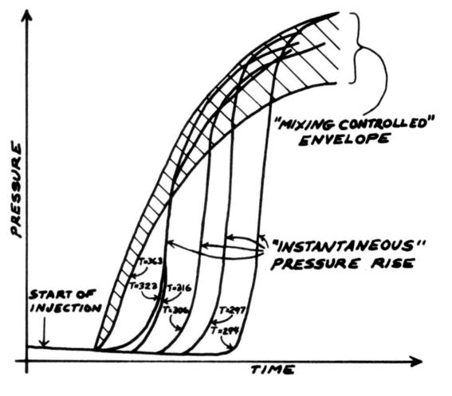

谢谢你，凯克教授。谢谢你，菲利普·休斯。你刚刚写了我论文的“结论”一章。当您提高发动机燃料和空气的温度时，燃料开始燃烧得更快。

Thank you, Professor Keck. Thank you, Philip Hughes. You just wrote the "Conclusions" chapter of my thesis. As you raise the temperature of the engine's fuel and air, the fuel starts to burn sooner.

11 月 15 日

November 15

“尼克，他们要带我飞往休斯敦。斯伦贝谢希望我下来参观一下工厂，”我告诉他。

"They're going to fly me to Houston, Nick. Schlumberger wants me to come down for a plant trip," I told him.

“嘿，队长，太棒了。恭喜你。几年前，实验室的一名学生去面试了他们。他说，这是一次非常艰难的面试。他们问了他各种各样的技术问题，比如如何Spahk 插头工作正常，他们甚至在下午进行了电子测试，”尼克回答道。

"Hey, Cap'n, that's great. Congratulations. One of the students from the lab went to interview with them a couple of years ago. A real tough interview, he said. They asked him all kinds of technical questions, like how does a spahk plug work, and they even gave an electronics test in the afternoon," Nick answered.

我想，我最好把去年夏天的笔记忘掉。我真的最好了解一下火花塞的工作原理。在这里，我在简历上告诉那个人我是乔柴油发动机，我在发动机实验室工作。如果我不知道火花塞的工作原理，那可就不太好了。

I'd probably better brush off my notes from last summer, I thought. And I'd really better find out how a spark plug works. Here I've told the guy I'm Joe Diesel Engine on my resume, and I work in an engine lab. It wouldn't look good for me not to know how a spark plug works.

“尼克，请问火花塞是如何工作的？”

"Say, Nick, how does a spark plug work?"

“快到黑板上来吧，船长，”他说。

"C'mon over to the blackboard, Cap'n," he said.

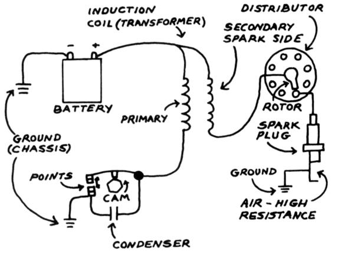

“看，heeyuh yuh 有电池，电压为 12 伏。它连接到这个变压器 heeyuh，点火线圈。然后你有接触断路器，这只是一个开关，在正确的时间打开和关闭。旋转的凸轮轴将其向上和向下推动。在变压器的次级侧，你有分配器的转子臂，当活塞位于正确的位置时，它使电流流向 spahk 插头。明白了吗？

"See, heeyuh yuh got the batt'ry, that's at 12 volts. An' that's connected to this transformuh heeyuh, the ignition coil. Then you got the contact breaker, that's just a switch that opens an' closes at the right time when the rotatin' cam shaft pushes it up an' down. On the secondary side of the transformuh, you got the distributor's rotor arm that makes the electric current go to the spahk plug when the piston's at the right place. Got it?"

“嗯。”

"Uh huh."

“很好。现在，当接触断路器闭合时，来自电池的电流会通过接触断路器回到地面。当它这样做时，它会在线圈的初级侧形成一个磁场。一旦磁场变得足够大， ，触点断路器再次打开，噗！初级侧的磁场崩溃了。电流被吸入电容器嘿哟，使次级磁场的电压大幅上升，达到20,000，甚至35,000伏。足够了伏特，使电流跳过 Spahk 插头的间隙，然后点燃发动机中的燃料。”

"Good. Now when the contact breaker closes, current from the batt'ry heeyuh goes through the contact breaker back to ground. When it does that, it stahts a magnetic field in the primary side of the coil. Once the field gets big enough, the contact breaker opens up again, and pow! The field in the primary side collapses. The current soughta gets sucked into the condensor heeyuh, and makes the volts in the secondary field go way up, to 20,000, even 35,000 volts. That's enough volts to make the current jump the gap in the spahk plug, an' it lights off the fuel in the engine."

它就像埃杰顿医生的闪光灯一样，只是威力稍弱一些。

It was just like Doc Edgerton's strobe light, only a little less powerful.

“这太棒了，尼克，”我说。“你介意我画一个小草图吗？”

"This is great, Nick," I said. "Do you mind if I make a little sketch of it?"

“Showah。把它放在一张小纸上，然后放进你的钱包里。也许有一天它会派上用场。”

"Showah. Put it on a little piece a paper an' put it in your wallet. It might come in handy someday."

11 月 17 日

November 17

那是飞往休斯敦的夜间航班，现在我知道了喷气发动机的工作原理，知道了静力学和 0 环、铆钉上的应力以及机翼在起飞前可以上下拍动多少次，所以飞机的感觉有所不同。掉下来了。但我没有时间坐公共汽车。

It was a night flight to Houston, and the airplane felt different now that I knew how jet engines worked, and I knew about statics and 0-rings and the stress on the rivets and how many times the wings could flap up and down before they fell off. But I didn't have time to take the bus.

我记得从布鲁塞尔陡峭地下降到波士顿。从那以后我改变了吗？我是米基奇教授所说的他们会让我成为的专业人士吗？坐在我旁边的两位商人讨论了希金斯退休后由谁来领导他们公司的阀门部门。最有可能的候选人有一座大房子和一个漂亮的妻子。

I remembered the steep descent into Boston from Brussels. Had I changed since then? Was I the professional that Professor Mikic said they would make me? The two businessmen in the seats beside me discussed who would head up the valve division of their company after Higgins retired. The most likely candidate had a big house and a pretty wife.

11 月 18 日

November 18

还有其他四位受访者，都来自好学校：普林斯顿大学、斯坦福大学、加州理工学院、圣母大学。其中两个看起来像足球运动员，这可能会给他们带来优势；在石油钻井平台上工作是一项艰苦的工作。我想知道我的学院风角框眼镜和细条纹西装是否会有所帮助或有害。

There were four other interviewees, all from good schools: Princeton, Stanford, Cal Polytech, Notre Dame. Two of them looked like football players, which might give them an edge; it's rough work, working on oil rigs. I wondered whether my preppy horn-rimmed glasses and pin-striped suit would help or hurt.

上午是关于工作的简报会。电影中，工作人员运行地球核心样本，一次钻探数十个小时，而年轻的、睡眠不足的现场工程师则在电脑上输入命令，并向甲板上的阿拉伯人发号施令。电影中，现场工程师在阿曼公司度假村休养两周，在泳池边放松聊天。看起来很令人兴奋。努力工作，赚大钱，五年后的生活——多么划算啊。我在西装外套口袋里的小笔记本里记下了一些笔记。

The morning was a briefing session about the job. Movies of crews running core samples of the earth, drilling for tens of hours at a time while the youthful, sleep-deprived field engineer no older than I punched commands into the computer and gave orders to the Arabian men on the deck. Movies of the field engineers relaxing and chatting next to the pool on their two weeks' recuperation at the company resort in Oman. It looked exciting. Hard work, good money, set for life in five years-what a deal. I jotted a few notes in the little notebook that fit in my suit jacket pocket.

整个早上没有任何评价，除了 Theunissen 和另一位面试官（一位拥有博士学位的英国人）这一事实。（也许他觉得自己失业了，我在我的小笔记本上记下了），当我们提出问题并试图表现出热情时，他们看起来都在打量我们，并在心里记下笔记。

The morning was nonevaluative, except for the fact that Theunissen and the other interviewer, a British guy with a Ph.D. (maybe he feels underemployed, I jotted in my little notebook), both looked as if they were sizing us up and taking mental notes as we asked questions and tried to look enthusiastic.

“现在，您认为现场工程师最大的事故来源是什么？” Theunissen 在第二部电影之后问道。这种危险一定会让他们很难雇用员工，即使他们有高薪。

"Now, what do you think the single largest source of accidents is for the field engineers?" Theunissen asked after the second movie. The danger must make it hard for them to hire people, even with the high money.

我建议说：“看起来这些装备上好像有很多重物。我想象偶尔会有什么东西落在某人的脚或脚踝上并压碎一些东西。” 我想，这似乎很合理。石油钻井平台不会每天都会爆炸。

I suggested, "It looks as if there's a lot of heavy stuff on those rigs. I'd imagine occasionally something lands on someone's foot or ankle and mashes something." It seemed plausible enough, I thought. Oil rigs don't blow up every day.

英国人记下了一张小纸条。特尤尼森说：“实际上，这是车祸；所以如果你是一个安全驾驶者，应该没问题。”

The British guy jotted down a little note. Theunissen said, "Actually, it's automobile accidents; so if you're a safe driver, you should be fine."

当然。您有得出该结论的报告副本吗？我可以浏览一下吗？

Sure. Do you have a copy of the report that came up with that conclusion? Could I glance through it for a second?

午餐时我们去了The Sagebrush。毕竟，这是休斯顿。我坐在英国人的黄色奔驰车的前座上，里面有棕色皮革内饰和电动门锁。

For lunch we went to The Sagebrush. This was, after all, Houston. I rode in the front seat of the British guy's yellow Mercedes with brown leather interior and electric door locks.

“你好，圣丹斯电影节，”特尤尼森对女服务员说。“我要和平常一样的酒；两杯血腥玛丽。” 然后他转身对我说：“点菜吧，喝光吧，这是石油工业的事。”

"Hello, Sundance," Theunissen said to the waitress. "I'll have the usual; two Bloody Marys." Then he turned my way and said, "Go ahead and order; drink up, it's on the oil industry."

“我要一杯橙汁，”我说。

"I'll have an orange juice," I said.

他的左眉毛高到了发际线。“什么？你不想喝点更烈的吗？”

His left eyebrow went up to his hairline. "What? Don't you want anything stronger?"

“我不喝酒。”我回答道。

"I don't drink," I answered.

斯坦福点了冰茶、普林斯顿牛奶、圣母姜汁汽水。我想知道他们是否不想喝酒，或者是否想在考试中保持敏锐。午饭后，在上车的路上，我在我的小本子上记下了一些笔记。

Stanford ordered iced tea, Princeton milk, Notre Dame ginger ale. I wondered whether it was because they didn't want to drink or whether they wanted to be sharp for the test. On the way to the car after lunch I jotted some notes on my little pad.

测试是小菜一碟，我花了几个小时的准备就完成了。这些都是暑期电子课程前两周的内容，再加上六点一十一的前十五分钟的一些内容。加州理工学院是双 E 成绩全 A 的学生，看起来特别想在半小时的测验中取得好成绩。

The test was a piece of cake, what with the couple of hours of preparing I'd done. It was all stuff from the first two weeks in the summer electronics course, plus a little stuff from the first fifteen minutes of six one eleven. Cal Polytech, a double E with straight A's, looked particularly intent on doing well on the half-hour quiz.

完成后十分钟，Theunissen 和那个英国人把它们还给了我们。满分十五分我得了十二分。加州理工学院有十一个，其他的都在十个以下。

Theunissen and the British guy handed them back ten minutes after we were done. I had twelve out of fifteen points. Cal Polytech had eleven, the others were all below ten.

哈。所以我毕竟不是一个傻瓜；只是在麻省理工学院，与周围的环境相比，你总是感觉自己很愚蠢。

Ha. So I'm not such a dummy after all; it's just that at MIT you always feel dumb by comparison to the environment.

现在是口试，最后是 Theu nissen 的面试。我已经准备好回答开头的问题了。他说：“现在，我想作为一个优秀的美国人，你拥有一辆汽车，作为一名优秀的工程师，你自己在这辆车上工作。你能告诉我火花塞是如何工作的吗？”

And now for the oral exam, the final interview with Theu nissen. I was ready for the lead-off question. He said, "Now, I suppose being a good American you own a car and being a good engineer you do your own work on it. Can you tell me how a spark plug works?"

我从钱包里拿出那张小纸片。“你知道吗，我听说这是你的问题之一。你介意我用笔记吗？”

I pulled the little sheet of paper out of my wallet. "You know, I heard that was one of your questions. Do you mind if I use notes?"

他的眉毛再次扬起。“谁给你的？其他哪一位候选人把它泄露给你的？”

His eyebrow soared again. "Who gave that to you? Which one of the other candidates leaked that to you?"

“真的，没有一个，”我回答道。“我实验室的技术人员告诉我，这是你们的标准面试问题。”

"None of them, really," I answered. "The technician in my lab told me it was a standard interview question for you guys."

“好吧，”他难以置信地说。“听着。我知道你是个聪明的孩子。我知道你能胜任这项工作。你想要这份工作吗？”

"Okay," he said incredulously. "Look. I know you're a smart kid. I know you can do the work. Do you want this job?"

我想知道是公司面试手册在说话还是特尤尼森本人在说话。

I wondered whether it were the corporate interview manual talking or Theunissen himself.

“我想要钱，”我回答。

"I want the money," I answered.

“你已经告诉过我了。我很欣赏你的诚实。但是你想要这份工作吗？如果你可以做任何你想做的事，你会做什么？”

"You already told me that. I appreciate your honesty. But do you want the job? What would you do if you could do anything you want?"

另一个有问题的问题。但要诚实回答。这是霍普金斯大学的迪安·胡克在我准备去参加罗德奖学金面试时告诉我的（我没有得到）。诚实地回答，说出你想到的第一件事，你就会脱颖而出。大多数人都会尝试告诉面试官他想听什么，而优秀的面试官可以在你这样做时看出。

Another loaded question. But answer honestly. That's what Dean Hooker at Hopkins told me when I was about to go to my interview for a Rhodes Scholarship (I didn't get it). Answer honestly, say the first thing that pops into your mind, and you'll stand out. Most people try to tell the interviewer what he wants to hear and a good interviewer can tell when you're doing that.

“嗯，你知道，我是一名环保主义者，我很欣赏你们所做的事情——我的意思是我有时也开车——但我真的很想致力于让管道的另一端，用户端，更高效。也许在工厂做一些咨询，发明一些更高效的产品。”

"Well, you know, I'm kind of an environmentalist, and I appreciate what you guys do-I mean I drive a car sometimes, too-but I'd really like to work on making the other end of the pipeline, the user end, more efficient. Maybe do some consulting in factories, invent some products that are more efficient."

似乎越来越多的是他，而不是面试手册。“那你为什么不现在就这么做呢？” 他问。

It seemed to be more and more of him, not the interview manual. "So why don't you do that now?" he asked.

“有积蓄很有帮助。我想我可以为你工作五年，看看世界，然后就这么做。”

"It helps to have a nest egg. I figure I could work for you five years, see the world, and then do that."

他回答说：“你知道，这本来是我的计划，但五年后，薪水很高，他们给了我巨额奖金让我进入管理层，所以我就来了。你对这份工作还有其他顾虑吗？”

He answered, "You know, that was my plan originally, but after five years, the pay was great and they offered me a huge bonus to move into management, so here I am. Do you have any other concerns about the job?"

“我多久能回家一次？我父亲病了，我希望在他离开我们之前每两年能见到他不止一次。”

"How often could I come home? My father's been ill, and I'd like to be able to see him more than once every two years before he leaves us."

特尤尼森对那个人只是微微扬起了眉毛。“我们公司每年可以送你一次回家。除此之外，你就得靠自己了。”

Theunissen raised his eyebrow only slightly on that one. "We can get you home once a year on the company. Beyond that you're on your own."

正确的。从罗利达勒姆 至 吉隆坡 的往返机票是多少？

Right. What's the round-trip airfare from Raleigh-Durham to Kuala Lumpur?

他继续说道：“好吧，我们可能会给你一个报价。祝你一路顺风回家。”

He continued, "Well, we'll probably make you an offer. Have a good flight home."

在去机场的出租车上，我把手伸进外套口袋，在小本子上做了一些进一步的记录。呃哦。我把它留在桌子上了。他们会找到它，将笔迹与测试进行比较，并了解我内心深处的想法和观察。

In the cab on the way to the airport, I reached into my coat pocket to make some further notes in my little pad. Uh oh. I left it on the table. They'll find it, compare the handwriting with the tests, and see my innermost thoughts and observations about them.

有时决定权不是你的。

Sometimes the decision is not yours.

# 章节

# C H A P T E R

# 19

# 19

# 不，不是

# No It Isn't

漩涡水流......（查尔斯）冷静的查尔斯涉水，感觉到从齐腰深的灰烬之前的冲突中醒来的新鲜水花的入侵，不知道它将如何结束。胸深，眼睛深，希望我有一个朋友，我所有的战斗都如此艰苦，我所有的努力都导致……归于……虚无……

Swirling Waters ... (the Charles) Cool Charles wading, senses invading fresh splashed wake from clashes before ashes waist deep now, don't know how it will end. chest deep, eye deep, wish I had a friend All my battles so hard fought, All my efforts lead ... to ... nought...

11 月 19 日

November 19

有人把这首诗钉在我公寓对面的墙上。我以为去年 12 月沃森事件让我获得了免费食宿。但是不！研究所的环境并没有松懈。

Somebody'd pinned the poem on the wall across from my apartment. And I thought I'd earned my free room and board last December with the Watson incident. But nooooo; the institute environment does not relent.

我给约翰·多尔西打了电话。“看看你是否能找出是谁把它放在那里的，”他说。“也尝试争取其他一些学生的帮助。”

I called John Dorsey. "See whether you can figure out who put it up there," he said. "Try to enlist the help of some of the other students, too."

楼下的大厅里正在进行杜松子酒游戏。埃尔登是四名球员之一。“我不知道我是否能熬过这个学期，”他说。

Downstairs the gin game was going on in the hall. Eldon was one of the four players. "I don't know whether I'm going to make it through the term," he said.

啊，嫌疑人。“为什么不？” 我问。

Ah, a suspect. "Why not?" I asked.

“我一直想成为一名宇航员。要成为一名任务专家，你需要博士学位，更不用说能够跑完 2 分 30 秒的马拉松了。但要从这里获得博士学位，我” “我需要的 A 多于 B，而我在两门课上力争 C，而我只是大二学生。如果我得到两个 C，那就是秋千或游泳，”他说。

"I've always wanted to be an astronaut. To be a mission specialist you need a Ph.D., not to mention being able to run a sub 2:30 marathon. But to get a Ph.D. from here I'll need more A's than B's and I'm pushing C's in two of my classes and I'm only a sophomore. If I get two C's, it'll be swing or swim," he said.

"What do you mean?" I asked him.

“你知道吗，摇摆……” 他跳了起来，用一只手臂抓住了蒸汽加热管，整个人都软了，头软软地向前垂了下来。

"You know, swing . . ." and he jumped up and caught the steam heating pipe with one arm and let the rest of himself go limp and his head fall limply forward.

“你做得非常好，埃尔登。我仍然认为你应该打包工程并前往纽约进行一些试镜。”

"You do that really well, Eldon. I still think you should bag engineering and head to New York for some auditions."

“等等，我还没说完。”他强调道。“……或者游泳。” 他松开管子，俯卧在地板上，胳膊和腿伸直，就像在东河里那样。

"Wait, I'm not through," he said emphatically. "... or swim." He let go of the pipe and lay prone on the floor with his arms and legs stretched out the way they do in the East River.

是时候换个话题了。“你认为爱国者队能进入季后赛吗？”

Time to change the subject. "Do you think the Patriots will make it to the playoffs?"

“谁在乎？” 埃尔登说。“这是什么，国家非推论日还是什么？”

"Who cares?" Eldon said. "What is this, national non sequitur day or something?"

“是的，”辛迪说。“我一直在读一本关于抑郁症的书。书上说，每当人们以任何方式谈论自杀时，你都应该让他们谈论它。他们想要谈论它，就像他们在寻求帮助一样。”

"Yeah," Cindy said. "I've been reading a book about depression. It says that whenever people talk about suicide, in any way, you should let them talk about it. They want to talk about it, like, they're asking for help."

“好吧，”我说。“继续说吧，埃尔登。”

"Okay," I said. "Keep talking, Eldon."

“嗯，你知道有些杂志会宣传如何做到这一点。有书籍。有邮购套件。”

"Well, you know there are magazines that advertise how to do it. There are books. There are mail order kits."

我试图让他放心。“听着，你不能去找你的一位教授，让他帮助你更好地理解这些材料吗？你仍然可以从每门课中获得 B，并在下学期获得 A。”

I tried to reassure him. "Look, can't you go to one of your professors and have him help you understand the material better? You can still probably pull a B out of each of the classes and go for the A next term."

埃尔登回答说：“我试过了。但这家伙对他有这样的态度，就像他一直问我问题，而且他喜欢让我觉得自己很愚蠢。然后我去找另一位教授，同样的事情发生了。我想我会在两次罢工时停下来。这就像“如果你自己无法弄清楚，孩子，你就不属于这里。当你在那个满是大房间的中间时，没有人会牵着你的手”现实世界中的绘图台和计算机终端。”

Eldon answered, "I tried that. But the guy had this attitude about him, like he kept asking me questions, and it was like he enjoyed making me feel stupid. Then I went to another professor and the same thing happened. I figured I'd stop at two strikes. It's like 'If you can't figure it out for yourself, kid, you don't belong here. Nobody's going to take you by the hand when you're in the middle of that big room full of drafting tables and computer terminals in the real world.'"

"Did you write that poem?" I asked him.

他演过凯瑟琳·赫本。“诗，什么诗？我不知道你在说什么……”

He did Katharine Hepburn. "Poem, what poem? I have no idea what you're talking about...."

“得了吧，施威心。承认吧。” 我回到转向架。

"Come on, Schweetheart. Admit it." I went back to Bogie.

“不，说实话，我不知道你在说什么。” 这不是埃尔登。

"No, seriously though, I don't know what you're talking about." It wasn't Eldon.

黛安娜走进她的房间，拿出一个尼龙套索。“我在大二那年捡到了这个作为黑客。我在愚人节那天带着它。真的吓坏了导师；他把它从我手中拿走了，并在年底归还给我。看看它。高-优质尼龙 - 它可能可以承载 500 磅。”

Dianne went into her room and brought out a nylon noose. "I picked this up as a hack my sophomore year. I carried it around on April Fools Day. Really freaked out the tutor; he took it away from me and gave it back at the end of the year. Just look at it. High-quality nylon-it'd probably carry 500 pounds."

埃尔登精神一振。“这样一来，我们两三个人就可以聚在一起，一起狂欢了。”

Eldon perked up. "With that, two or three of us could get together and have a gang hang."

“来吧，伙计们。让我们快乐起来。这个地方还不错，”我说。

"Come on, guys. Let's be happy. This place isn't so bad," I said.

“哦耶？” 埃尔登回答道。“好吧，我今天怎么样？我已经告诉过你，我已经在通往两个 C 的路上了。这是基于我今天回来的两次测试。两次测试都比班级平均分低 15 分。今晚我妈妈打电话来，她说说他们为我感到多么自豪，他们多么高兴我如此成功，以及在西尔斯之夜工作筹集学费是多么艰难，但这是值得的。然后在返回航空电子实验室的路上，我认识了三个人或者以为我知道在无限的走廊上没有打招呼；他们的眼睛只是向前看。”

"Oh, yeah?" Eldon answered. "Well, how about my day today? I already told you I'm well on my way to two C's. That was based on the two tests I got back today. Both were 15 points below class average. My mother called tonight and she said how proud they are of me and how happy they are I'm so successful and how it's rough working at Sears nights to pull together the money for tuition but it's worth it. Then on the way back to the avionics lab three people I knew or thought I knew on the infinite corridor didn't say hi; their eyes were just beaming forward."

“他们可能只是专注于解决一些问题或其他事情，”我说。“我们都有糟糕的日子。”

"They were probably just preoccupied with some problem set or something," I said. "We all have bad days."

“是的，我想你是对的，”埃尔登说。“但有时感觉麻省理工学院是一条我必须杀死的巨龙。”

"Yeah, I guess you're right," Eldon said. "But sometimes it feels like MIT is a dragon I have to slay."

11 月 22 日

November 22

这次导师会议是为了准备一部关于被核武器袭击的电视电影《后天》。

The tutor meeting was to prepare for "The Day After," the madefor-TV film about being nuked.

“现在我希望大家在播出后留意任何警告信号，”约翰·多尔西说。“你可能想成立某种讨论小组来讨论这个问题。让学生们讨论一下。这部电影包含可能令人反感的材料。建议观众谨慎行事。该研究所担心这可能会让人们感到沮丧，可能会出现大规模的暴力事件。”自杀。我们必须采取措施防止这种情况发生。”

"Now I want you all to be on the lookout for any warning signs after it's aired," John Dorsey said. "You might want to have some kind of discussion group about it. Let the students talk through it. The film contains material that may be offensive. Viewer discretion is advised. The institute is worried that it might depress people, that there may be mass suicide. We have to take steps to prevent that."

我整个晚上都在看电影，而不是看电视。从学生中心图书馆回来的路上，无限长的走廊上上下下都有指示牌。为什么没有希望？一个说。为什么该机构毫无希望？我想知道这是否是某人想出的一个恶心的笑话，一种将读者推入危及生命的抑郁症的方式。我把我能拿到手的所有东西都撕下来了。

I spent the evening of the movie reading, not watching TV. On the way back from the student center library, there were signs up and down the infinite corridor. WHY IS THERE No HOPE? one said. WHY IS THE INSTITUTE HOPELESS? I wondered whether it was somebody's idea of a sick joke, a way to push the reader into a life-threatening depression. I ripped down every one I could put my hands on.

电影结束后我举办了一场牛奶和饼干休息会。“没那么好，”黛安娜说。“角色发展根本不存在。”

I hosted a milk and cookies break after the movie. "It wasn't that great," Dianne said. "The character development just wasn't there."

“是的，”埃尔登说。“特效完全是假的。如果他们想要真正有效，他们应该展示广岛和长崎的真实电影。当真实的事情发生时，破坏将比他们在电影中展示的要严重得多。”

"Yeah," Eldon said. "And the special effects were like totally fakey. If they wanted to be really effective they should have shown the real films from Hiroshima and Nagasaki. When the real thing happens the destruction will be a lot worse than they showed in that movie."

“会，埃尔登，会。在谈论这类事情时总是使用条件句。”

"Would, Eldon, would. Always use the conditional when talking about these kinds of things."

11 月 23 日

November 23

学生报纸《科技报》刊登了一篇关于黑人女性迪恩·霍普被解雇的报道。这解释了这些迹象。

The Tech, the student newspaper, ran a story about the firing of Dean Hope, a black woman. That explained the signs.

11 月 24 日

November 24

我和我的同事正在讲黄色笑话。大厅的门开着。有时你会忘记实验室里也有女性。你所说的话可能会杀死某人。但这些笑话很有趣，当其他人嘲笑我的时候，我感觉自己就像其中一员。谈话转向了对实验室以及机甲 E 部门中各个女性的外貌进行排名。女人在一起的时候都会做这种事吧？这很自然，对吧？

My office mates and I were telling dirty jokes. The door to the hall was open. Sometimes you forget that women are in the lab, too; that what you say might kill someone. But the jokes were funny, and I felt like one of the guys when the other guys laughed at mine. The conversation drifted toward ranking the looks of the various women in the lab, and in the Mech E department in general. Women do this kind of thing when they're together, right? It's natural, right?

其中一个人说：“是啊，玛丽的身材很好，但她的脸没那么好看。” 我们都有点笑了。她走过开着的门，没有朝里看。我不知道她是否听到了。这是我最后一次见到她。

One of the guys said, "Yeah, Mary's got a nice body but her face isn't that great." We all sort of chuckled. She walked by the open door, didn't look in. I wondered whether she heard it. It was the last time I saw her.

我不知道她为什么这么做。谁知道这是否是最后一条小评论？谁知道是不是我没有为她辩护呢？从第一个学期开始我们就有点疏远了。我会打招呼，她会给我那种高级之家强迫性的微笑，这实际上是对微笑的模仿，因为在这个地方怎么可能有人快乐呢？但她在户外俱乐部有朋友，而且有传言说她有男朋友，所以我没有责任问她为什么不再和我说话了。我们是自己灵魂的主人，对吗？这不是我的错。这不是我的错。这不是我的错，是吗？

I don't know why she did it. Who knows whether it was that last little comment? Who knows whether it was the fact that I didn't say anything in her defense? We'd sort of drifted apart since the first term. I'd say hello and she'd give me that Senior House forced smile that is really a parody on a smile because how could anyone possibly be happy at this place? But she had her friends in the outdoors club and rumor had it she had a boyfriend, so it wasn't my responsibility to ask her why she wasn't talking to me much anymore. We're the masters of our souls, right? It wasn't my fault. It wasn't my fault. It wasn't my fault, was it?

这不是压力。她太聪明了，不会这么做。也许这就是孤独吧。但她有男朋友。也许这是麻省理工学院过度机械化的世界观所引发的绝望，在这种世界观中，逻辑和理性是神，灵性、灵魂和人性充其量被视为无关紧要，最坏的情况是不存在。

It wasn't the pressure. She was too smart to let that do it. Maybe it was the loneliness. But she had a boyfriend. Perhaps it was the hopelessness spurred on by MIT's overmechanistic worldview, in which logic and reason are gods and spirituality, soul, and humanity are dismissed as irrelevant at best and nonexistent at worst.

第二天早上，切特邀请我去他的办公室。他关上了我身后的门。

The following morning Chet asked me into his office. He closed the door behind me.

“坐吧，”他说。“我有一些非常坏的消息。昨晚玛丽结束了自己的生命。”

"Have a seat," he said. "I've got some very bad news. Last night Mary took her own life."

她把它带到哪里去了？

Where'd she take it?

不过实话说。“怎么……怎么……？” 我问。

But seriously. "How'd ... How'd ... ?" I asked.

“今天早上他们在她的雪佛兰车里发现了她。我已经和每个人核实过。校园警察、她的房东、剑桥警察、院长办公室。我不断听到同样的故事，但我不敢相信它发生了。这是玛丽，好吧，”切特回答道。他的眼睛眨了一下。“她把一些管子从车尾管插入乘客区。她把车停在奥尔巴尼街。然后她就睡着了。”

"They found her in her Chevette this morning. I've checked with everyone. Campus police, her landlord, Cambridge police, the dean's office. I keep getting the same story, but I can't believe it happened. It's Mary all right," Chet answered. His eyes blinked a little. "She put some tubing from the tail pipe of her car into the passenger section. She was parked over on Albany Street. And she just sort of fell asleep."

让我们看看，我想知道。如果汽车以 800 rpm 的转速怠速运转，排量为 2 升，则进入汽车的体积流量将为每分钟 400 升，乘以废气中一氧化碳的百分比。我们必须为汽车乘客部分的一氧化碳浓度建立一个微分方程，假设流入速率和排气速率相等。这有点像填充一个漏水的刚性气球，另一端有一个洞。我们必须对乘客的呼吸频率做出另一个假设。计算 2 升肺活量和每分钟 20 次呼吸，这意味着乘客舱每分钟需要 40 升气体。现在为了模拟肺部吸收一氧化碳的速率，我们需要......

Let's see, I wondered. If the car is idling at, say 800 rpm, and the displacement is, say, 2 liters, then the volume flow rate into the car will be 400 liters per minute, times the percentage of carbon monoxide in the exhaust gas. We'll have to set up a differential equation for the concentration of carbon monoxide in the passenger section of the car, assuming equal inflow rates and exhaust rates. It's sort of like filling up a leaky rigid balloon with a hole in the other end. We'll have to make another assumption about the breathing rate of the passenger. Figure a 2-liter lung capacity and 20 breaths per minute, that means 40 liters per minute of passenger compartment gas. Now to model the rate of carbon monoxide uptake into the lungs we need to ...

内达勒特。玛丽的声音几乎听得见，就像在热课上，当有人的手表在整点响起时，她说“Nedalert”。就是这样。我受够了。他们抓住了我。

Nerdalert. Mary's voice was almost audible, like the time she said, "Nerdalert" when somebody's watch beeped at the top of the hour in Thermo class. That's it. I'm done. They've got me.

我胃里的结绷紧了。我也不敢相信。当你二十六岁的时候，你可能听说过死亡，也许失去了一些宠物，但如果你的父母都还活着，而且你真正熟悉的人都没有去世，你仍然会觉得对它免疫。

The knot in my stomach tightened. I couldn't believe it, either. By the time you're twenty-six you may have heard of death, maybe lost a few pets, but if both your parents are still alive and no one you know really well has passed away, you still feel kind of immune to it.

“追悼会将于下周日晚上在教堂举行，”切特说，“在教堂里。嘿，孩子，顺便说一句，我对你的工作提出了批评，但原因是为了帮助你学习，这样你就可以出去“在这里，你能够胜任并完成人们对拥有麻省理工学院学位的人所期望的良好专业工作。你的实验技术确实很出色。你很擅长解决问题。”

"The memorial service will be next Sunday night," Chet said, "in the chapel. Hey, kiddo, by the way, I've had my criticisms of your work, but the reason is to help you learn so you can go out of here and be competent and do the good professional work that people expect out of people with MIT degrees. You've really come along in your experimental techniques. You're good at solving problems."

他称赞了我。我简直不敢相信。切特称赞了我。他所说的一定是真的，因为切特无法说谎，即使是在胁迫下。

He paid me a compliment. I couldn't believe it. Chet paid me a compliment. And what he said must be true, because Chet is incapable of lying, even under duress.

我下楼去拿了一些宝丽来照片，用于我论文的仪器部分。尼克在钻床上。

I went downstairs to take some Polaroids for the apparatus section of my thesis. Nick was at the drill press.

广播中播放着比莉·哈乐黛的版本“What's New?”。

"What's New?"-the Billie Holiday version-played on the radio.

尼克把手放在我的肩膀上说：“发生了一件可怕的事情，真的是一件可怕的事情。永远不要让这样的事情发生在你身上，好吗，船长？主只是希望你继续这样做”尽你所能；这才是最重要的。你会经历一些糟糕的时光，但你会挺过去的。这一切发生得太快了。”

Nick put his hand on my shoulder and said, "That's a terrible thing that happened, just a terrible thing. Don't ever let anything like that happen to you, OK, Cap'n? The Lord just wants you to keep doin' the best you can; that's all that matters. You'll have some bad times but you'll make it through. It happens too fast by itself."

我当时没有哭。我很坚强；我可以接受。我可以接受研究所提供的任何东西。我把宝丽来照片交给了夏洛特·埃文斯；她帮我打论文并帮助我计算数据，每页收费 3 美元。她也刚刚从切特那里听到了这个消息。

I didn't cry then. I was tough; I could take it. I could take anything the institute could dish out. I delivered the Polaroids to Charlotte Evans; she was typing my thesis for me and helping with the figures for $3 a page. She had just heard the news from Chet as well.

“可怜的东西，”她在办公桌后面说道。“我感觉很糟糕。你知道她为什么这么做吗？”

"The poor thing," she said from behind her desk. "I feel just awful about it. Do you have any idea why she did it?"

“不，不是真的。我们最近没怎么说话。我现在感觉有点糟糕，好像我应该问她是否有什么事情困扰着她。但我们渐行渐远，现在我们再也不会回到一起了，不是在这里。”反正。”

"No, not really. We didn't talk a lot recently. I feel kind of bad now, like I should have asked her whether something was bothering her. But we drifted apart and now we'll never drift back together, not here anyway."

夏洛特安慰道：“现在你别再责怪自己了。每个人都要为自己的行为负责，而不是别人的行为。再说了，每年的这个时候，很多人都会过得很艰难，比如圣诞节快到了。”这些天你无法接近精神科医生，他们的预约非常多。圣诞节和春天，很多人都会感到沮丧，尤其是单身人士。”

Charlotte said comfortingly, "Now don't you go blaming your self. Everyone is responsible for his own actions and no one else's. Besides, a lot of people have a hard time this time of year, what with Christmas coming up and all. You can't get near a psychiatrist these days they're so heavily booked. Christmastime and springtime, a lot of people get depressed, especially if they're single."

我举起手说：“有罪。” 我想知道她怎么知道很难安排时间去看精神科医生。

I raised my hand and said, "Guilty." I wondered how she knew it was hard to schedule time with a psychiatrist.

夏洛特开始谈正事。“所以我输入了实验的介绍和描述。我还输入了实验室照片的空白标题。这是手稿供您阅读和证明。” 她递给我完整的马尼拉文件夹。

Charlotte got down to business. "So I've typed the introduction and the description of the experiment. And I've typed the blank headings for the photos of the lab. Here's the manuscript for you to read through and proof." She handed me the full manila folder.

“谢谢，夏洛特。我几乎能尝到切特的签名了。”

"Thanks, Charlotte. I can almost taste Chet's signature."

“没问题。八十一美元。如果你有的话，我更喜欢现金。”

"No problem. That'll be eighty-one dollars. I'd prefer cash if you have it."

“我得去趟银行。五点前回来。”

"I'll have to go to the bank. I'll be back by five."

“很好，”我离开办公室时她说。“还有佩珀，”她补充道，“不要工作太辛苦。”

"Good," she said as I left the office. "And Pepper," she added, "don't work too hard."

“没有这样的……”我从我的标准回答中停了下来。“呃，好吧。我会尽量不这样做。”

"There's no such...." I paused from my standard response. "Uh, OK. I'll try not to."

三天后。两个看起来有点像玛丽的女人，只是年龄更大，她们在我家门口附近的走廊里看起来迷失了方向。我记得在我家门附近的走廊里迷失了方向。她们可能是我的姐姐。他们的眼睛仍然是红色的。

Three days later. Two women who looked a little like Mary, only older, looked lost in the corridor near my door. I remembered feeling lost in the corridor near my door. They could have been my older sisters. Their eyes were still red.

“你……你知道我们怎样才能进入这个办公室吗？” 年长的问道。“玛丽·帕特森是我们的妹妹，我们是来检查她的物品的。”

"Do ... do you know how we can get into this office?" the older one asked. "Mary Patterson was our younger sister, and we've come to go through her belongings."

“呃，哎呀，我不知道。我可以跑下楼去实验室看看她的同事是否在附近。” 他们不是。

"Uh, gee, I don't know. I can run downstairs to the lab to see whether any of her office mates are around." They weren't.

“我给校园警察打电话，他们可以来给你开门，”我说。“顺便说一句，我叫白胡椒。”

"Let me call campus police and they can come and open up the door for you," I said. "By the way, my name's Pepper White."

“哦，原来你是佩珀，”年长的说。“玛丽谈了很多关于你的事；她说她真的很喜欢你，还告诉我们你做过的一些事情。”

"Oh, so you're Pepper," the older one said. "Mary talked a lot about you; she said she really liked you, and she told us about some of the things you'd done."

这是什么，“生活多美好”主题的变体？听着，我感觉很糟糕，因为我不知道她把我当作好朋友，即使她没有向我打招呼。这个地方是一个盐矿，除了开采盐之外没有时间做任何事，更不用说试图拉住一个在阿卡普尔科度假时给我寄来一张明信片并署名“爱你，玛丽”的人，她给了我笔记的原件两年前我错过了热和流体课程，并为自己复印了一份，她出于抑郁症与我出去约会了几次。这不是我的错，是吗？

What is this, a variation on the It's a Wonderful Life theme? Look, I feel bad enough as it is without knowing that she thought of me as a good friend even when she didn't say hello to me. This place is a salt mine and there's no time to do anything but mine salt, much less try to pull someone who sent me a postcard from her vacation in Acapulco and signed it "Love, Mary," who gave me the originals for the notes for the Thermo and Fluids classes I missed two years ago and made photocopies for herself, who went out on a couple of dates with me, out of a depression. It wasn't my fault, was it?

我说：“呃，是的。我们都非常想念她。”

I said, "Uh, yeah. We all miss her very much."

“我们的父亲是一位物理学家，”她说。“我们想翻阅她的笔记本，向他展示一些她正在做的事情的例子。,,

"Our father's a physicist," she said. "We'd like to go through her notebooks to give him some examples of what she was working on.,,

校园警察赶到并打开了门。我们把他们从 U-Haul 取来的纸板箱组装起来，装满玛丽的笔记本，然后把它们搬到租来的货车上。

The campus policeman arrived and opened the door. We assembled the cardboard boxes they'd picked up from U-Haul, filled them with Mary's notebooks, carried them to the rented van.

“那鱼缸呢？” 我问他们。

"What about the fish tank?" I asked them.

“我们暂时就这样吧，”姐姐说。“你能确保有人喂鱼并清洁过滤器几周吗？”

"We'll leave it for now," the older sister said. "Could you make sure someone feeds the fish and cleans the filter for a couple of weeks?"

“当然，”我说。“呃，我……对发生的事情感到非常抱歉。祝你一路平安回家。”

"Sure," I said. "Say, I'm uh . . . really sorry about what happened. Have a safe drive home."

“谢谢再见。”

"Thanks. Bye."

那晚。本和玛丽办公室的收音机大声播放着 WBCN 的摇滚音乐，办公室的门开着。

That night. The radio in Ben and Mary's office played loud rock music from WBCN and the office door was open.

"Yo, Ben. Could you turn that down a little bit?" I asked him.

“嗯？” 他说，从他的问题集中抬起头来。“哦。是的。当然。抱歉，声音这么大。我想我想避开这个地区可能出现的任何邪灵；我的意思是，现在玛丽走了，深夜这里有点怪异。每次我走路走进办公室，我以为会在办公桌前看到她，或者朝相反的方向走去，但她已经不在了。我仍然不敢相信这一切发生了。唯一剩下的就是鱼缸。我想知道鱼是否知道里面有什么继续，”他说。

"Huh?" he said, looking up from his problem set. "Oh. Yeah. Sure. Sorry it's so loud. I guess I want to sort of ward off any evil spirits that might be in the area; I mean it's kind of spooky here late at night now with Mary gone. Every time I walk into the office, I expect to see her at her desk or walking the other way, and she's never there anymore. I still can't believe it happened. The only thing that's left is the fish tank. I wonder whether the fish know what's going on," he said.

“哦，这让我想起了。你知道她把那盒鱼食放在哪里吗？我答应过她的家人，我会照顾他们一段时间。”我说。

"Oh, that reminds me. Do you know where she kept the box of fish food? I promised her family I'd take care of them for a while," I said.

我们俩把食物撒在水面上，鱼儿就跑到水面上吃东西。

We both sprinkled the food on the water and the fish scurried up to the surface to eat.

本继续说道。“就像我试图想象她的痛苦，你知道，她的感受是什么，是什么让她这么做。她也很聪明。这是最可怕的事情。她每天都读《纽约时报》，知道关于什么的一切。世界上所有这些小国家都在发生这种事。我想知道她是否知道一些我们不知道的事情。”

Ben continued. "It's like I'm trying to imagine her pain, you know, how she felt, what made her do it. She was so smart, too. That's the scariest thing. She read the New York Times every day, knew everything about what was going on in all these little countries around the world. It's like I wonder whether she knew something we don't know."

我回答说：“谁知道呢，也许我们会在夜班时再次见到她，我们就能问她。现在已经过了我的睡觉时间了。如果你想把收音机调回来，那就继续吧。”

I answered, "Who knows, maybe we'll see her again on the night shift and we'll be able to ask her. For now it's past my bedtime. If you want to turn the radio back up, go ahead."

“谢谢，”他说。“别紧张。”

"Thanks," he said. "Take it easy."

睡觉前，我从高级之家的文件柜中取出布告栏上的手写诗，并将笔迹与玛丽给我的第一学期液体笔记进行比较。笔记本上的字迹与墙上的字迹不符。这不是她的，但又是谁的呢？

Before bed I took the bulletin board's handwritten poem out of my filing cabinet at Senior House and compared the handwriting to the first-semester Fluids notes that Mary gave me. The handwriting in the notebook didn't match the handwriting on the wall. It wasn't hers, but whose was it?

我躺在床上，听着收音机里播放的“Soft Hits”，渐渐进入了梦乡。

I lay in bed with "Soft Hits" playing on the radio and gradually drifted off to sleep.

那是晚上，玛丽站在教堂前，克雷斯吉和学生中心对面。

It was night and Mary was standing in front of the chapel, across from Kresge and the student center.

“嗨，佩珀，”她说。

"Hi, Pepper," she said.

“嗨，玛丽。有什么新鲜事吗？”

"Hi, Mary. What's new?"

“哦，不多，你呢？” 她说。

"Oh, not much, how about you?" she said.

“我也是。哎呀。你一点也没变。”

"Me neither. Gee. You haven't changed a bit."

“你是什么意思？” 她朝我伸手问道。

"What do you mean?" she asked, reaching toward me.

“等一下，”我回答道。“你死定了。”

"Wait a minute," I answered. "You're dead."

“嗯？哦。是的。当然。再见……”

"Huh? Oh. Yeah. Sure. Adieu...."

当斯波克先生和柯克船长被传送到企业号星舰时，她闪烁了一会儿就消失了。

And as when Mr. Spock and Captain Kirk are beamed up to the Starship Enterprise, she shimmered for a few moments and disappeared.

我的头从枕头上猛地抬起来。琳达·朗斯塔特 (Linda Ronstadt) 与纳尔逊·里德尔 (Nelson Riddle) 管弦乐团一起演唱了这首轻柔的歌曲：

My head jerked up from the pillow. Linda Ronstadt sang the soft hit with the Nelson Riddle orchestra:

...但是见到你真是太棒了，而且你很贴心，愿意伸出你的手...

... but seeing you is grand, and you were sweet, to offer your hand ...

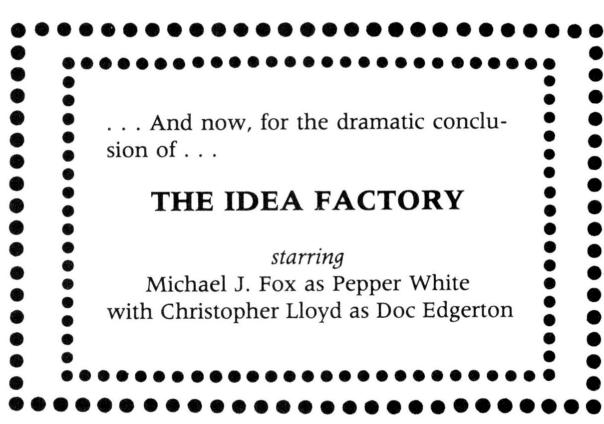

# 章节

# C H A P T E R

# 20

# 20

# 质量控制

# Quality Control

“风随意思吹，你听见风的声音，却不知道从哪里来，到哪里去……”

"The wind bloweth where it listeth, and thou hearest the sound thereof, but canst not tell whence it cometh, and whither it goeth.... ..

——约翰福音 3:8

-JOHN 3:8

“……风……哭泣……玛丽”

"... and the wind . . . cries . . . Mary"

12月18日

December 18

我请海伍德教授推荐我参加博士资格考试。

I asked Professor Heywood to recommend me for the doctoral qualifying exams.

“嗯，”他说。“你想用博士学位做什么？-

"Hmmm," he said. "And just what is it that you'd like to do with a Ph.D.?-

我的朋友们可以叫我胡椒博士。此外，考试应该成为本书中非常好的章节。

My friends could call me Dr. Pepper. Besides, the exams should make for a really good chapter in the book.

“我想咨询。我想就如何节约能源向行业提供建议。这就是我来到这里的原因，我认为博士学位会有所帮助，”我回答道。“这会给我一定的可信度。”

"I want to consult. I want to advise industry on how to save energy. That's why I came here in the first place, and I think the Ph.D. would help," I answered. "It would give me a certain credibility."

“是的，会的，”他说。“但对于你想做的事情来说，这可能并不是真正必要的。事实上，对你来说，现在进入工业界，看看现实世界中的事情是如何运作的，可能会更有利。你三年或更长时间”花在博士学位上的费用就会涉及到机会成本。”

"Yes, it would," he said. "But it may not really be necessary for what you want to do. In fact, it may be much more advan tageous for you to go out into industry now and see how things work in the real world. The three years or more you'd spend on a Ph.D. would involve that opportunity cost."

“我不知道；我现在仍然想尝试一下预选赛。如果我现在不尝试，我永远不会参加。此外，你必须承认这将是一个很好的机会来回顾一下什么我在这里学到了。”

"I don't know; I'd still like to give the qualifiers a shot now. If I don't try now, I'll never do them. Besides, you have to admit it would be a great opportunity to review what I've learned here."

“你的成绩怎么样？”

"How are your grades?"

“呃，呃，我，呃......好吧，我有三个C，两个A，其余的B。但是其中两个C是我的第一个学期，第三个是在夏季电子课程中，所以他们不应该真的应该算吧？”

"Uh, er, I, uh ... well, I have three C's, two A's, and the rest B's. But two of the C's were my first term and the third was in a summer electronics class so they shouldn't really count, should they?"

“一切都很重要。你将受到两次打击。但如果你真的想这样做，我会写这封信。你必须在口头、书面和演示方面做得非常好考试了，所以我建议你好好准备。”

"Everything counts. You'll be going in with two strikes against you. But if you really want to do it, I'll write the letter. You'll have to do remarkably well on the oral, written, and presentation components of the examinations, so I advise you to prepare well."

“谢谢您，教授。”

"Thank you, Professor."

那天下午，切特摇了摇头。

That afternoon, Chet shook his head.

“你真的想经历这一切吗？” 他问。

"You really want to go through with it?" he asked.

“是的，切特。我必须尝试。我知道这是一个渺茫的机会，但该死的，这是美国，我们喜欢失败者，我们喜欢成为失败者。我整个月都会哼着《洛基主题曲》。 ”

"Yeah, Chet. I have to try. I know it's a long shot, but darn it this is America and we love an underdog, and we love to be underdogs. I'll be humming the 'Theme from Rocky' all month."

“好吧，我会在你的申请表上签字。不过要小心。好好学习，知道自己在说什么，否则他们会把你活活吃掉。”

"Well, I'll sign your application. But be careful. Study hard, and know what you're talking about; otherwise they'll eat you alive. "

“好吧，切特。我会尽力的。”

"Okay, Chet. I'll do my best."

限定词是他们在研究生和被称为“某某博士”之间设置的障碍。考试的存在有几个原因。首先，他们给了教授们性格中的虐待狂元素一个表达自己的机会。其次，他们将研究生群体中的谷壳与麦子分开。你看，如果让大家都轻松通过的话，更多的无能者就会被称为“某某医生”。如果他们让任何人通过，他或她可能会完成博士学位，顺利地通过普林斯顿大学或斯坦福大学助理教授的面试，并且在教授热力学概论时，被某个聪明的十九岁孩子活活吃掉。这比被麻省理工学院的一些教授活活吃掉更具破坏性，所以这种残忍是仁慈的。

The qualifiers are the barrier they put between graduate students and the ability to be called "Doctor So and So." The examinations exist for several reasons. First, they give the sadistic elements of the professors' characters an opportunity to express themselves. Second, they separate the chaff from the wheat of the graduate student body. See, if they made it easy for everyone to pass, more incompetents would be called "Doctor So and So." If they let anyone pass, he or she might finish a Ph.D., glibly sleaze through an interview for an assistant professorship at Princeton or Stanford, and, when teaching Intro Thermodynamics, be eaten alive by some bright nineteen-year-old. And that would be more devastating than being eaten alive by some MIT professors, so the cruelty is kind.

考试分为四个方面。周五是写作部分。四个专业领域各进行一小时的测试。每个学生在测试科目上都有一些选择，我选择了基础知识：流体、热、系统动力学和控制以及力学。然后周末就到了，让你流汗。我的意思是，我宁愿周一、周二、周三都这样，然后你消失去滑雪，看看你是否通过了，但这是他们的比赛，他们制定规则。

The examinations are in four areas. Friday is the written section. One hour of testing in each of four areas of specialization. Each student has some choices in the test subjects, and I chose the basics: Fluids, Thermo, System Dynamics and Controls, and Mechanics. Then the weekend comes just to make you sweat. I mean, I'd rather have it Monday, Tuesday, Wednesday, and then you disappear and go skiing and find out whether you passed, but it's their ballgame and they make the rules.

周一他们会对您进行口头检查。他们给你带来了一个问题；你有二十分钟的时间来查看它并尝试解决它，或者至少想出一些关于它的内容，然后你用二十分钟的时间提出你的解决方案和/或回答他们的问题。为了防止作弊，四十分钟的时间是连续的，不允许有时间从一个房间到另一个房间。因此，你从一个考场跑到另一个考场，以尽可能多地利用二十分钟的准备时间。

On Monday they examine you orally. They present you with a problem; you have twenty minutes to look at it and try to solve it or at least think up something to say about it, and then you present your solution and/or answer their questions for twenty minutes. To discourage cheating, the forty-minute periods are consecutive, with no time allowed to go from one room to the other. Thus you run from examination room to examination room, to have as much of the twenty minutes of preparation time as possible.

周二，您将展示您迄今为止的研究工作。这使他们能够评估您是否能够“进行研究”。

And on Tuesday, you present your research work to date. This enables them to evaluate whether you are able to "do research."

12月31日

December 31

还有二十天就到了。除夕。斯隆实验室里除了董先生和董太太之外没有人，这对中国夫妇穿过大厅，他们在电炉上煮着难闻的海藻。他们的除夕夜是二月。

Twenty days to go. New Year's Eve. No one in the Sloan Lab except Mr. and Mrs. Tung, the Chinese couple across the hall with the foul-smelling seaweed they cooked on their hot plate. Their New Year's Eve was in February.

独奏。事情就这样结束了。靠你自己。自己做。单独解决问题集。单独与牛顿，与拉格朗日。单独与教科书的作者在一起。模式识别，没有时间深入研究问题，而是从已制定的解决方案集中尽可能多地获取技巧。尝试问题；卡住了。查看解决方案集以获取提示。继续。再次卡住。再次查看解决方案集。

Solo. This is how it ends. By yourself. Do it yourself. Plow through the problem sets alone. Alone with Newton, with Lagrange. Alone with the authors of the textbooks. Pattern recognition, no time to look deep into the problems, just time to pick up as many tricks from worked-out solution sets as possible. Try problem; get stuck. Look at solution set for hint. Continue. Get stuck again. Look at solution set again.

当解决第二个或第三个相同类型的问题时，模式就变得更加清晰。然后你希望预选赛的问题将包括你已经内化的技巧。

By the second or third of the same type of problem the pattern becomes clearer. And then you hope the problem on the qualifiers will include the trick you have internalized.

10时30分，连董先生、佟太太也离开了。唯一剩下的噪音是玛丽的鱼缸里的过滤器从她办公室锁着的门里传来的声音。返回高级之家的路上，学院里空无一人。这条无边无际的走廊通常全天都挤满了人，但现在 319 步内却空无一人。其他所有走廊也是如此。只有书呆子中的书呆子在除夕夜11点30分学习。

At 10:30 even Mr. and Mrs. Tung had left; the only noise left was the filter from Mary's fish tank loud through the locked door of her office. On the way back to Senior House the institute was empty. The infinite corridor, normally populated at all hours, was empty for all of its 319 paces. So was every other corridor. Only a nerd's nerd studies at 11:30 on New Year's Eve.

1984年。更多动力学（林肯班，B+），加上静力学复习（希尔教授，B++，班上最高的B，不是A）。我从一本书跳到另一本书，缩小了概念上的差距。在静力学中，重量位于横梁上。在动力学中，重量上下移动。在系统动力学（大卫·米勒，海军A）中，重量上下移动，你将横梁称为弹簧。相同的重量，相同的梁。

1984. More Dynamics (Lincoln's class, B plus), plus review of Statics (Professor Hill, B plus plus, the highest B in the class, not an A). I skipped from book to book, closing the conceptual gaps. In Statics, the weight sits on the beam. In Dynamics, the weight moves up and down. In System Dynamics (David Miller, A with the navy guys), the weight moves up and down and you call the beam a spring. The same weight, the same beam.

1月2日

January 2

《环球报》在生活版块的前面有一篇搞笑的文章说：“我们学会了努力争取和‘需要’我们价值的外在象征，而不是享受学习、完成和掌握的过程，这是一个更糟糕的过程。”人类自然的满足。” 简而言之，这就是麻省理工学院。成绩是价值的外在标志。客观的、定量的，比如 SAT 成绩、智商、工资、银行余额、道琼斯平均指数、彩票号码。一切都是这样的。

The Globe article on the front of the Living section with the funnies in it said, "We learn to strive for and 'need' external symbols of our worth, instead of enjoying the process of learning, accomplishing, and mastering, which is a more natural human gratification." That's MIT in a nutshell. The grades are the external symbols of worth. Objective, quantitative, like an SAT score, like an IQ, a salary, a bank balance, a Dow Jones average, a lottery number. It's all such a crock.

我开始学习和掌握更多的流体力学。这是资格考试的外部动机最后一次让我更深入地内化流体的行为方式。我越来越清楚为什么薄荷派蒂的茶叶会落到杯子的中央。我想要了解的烟囱羽流不仅有锅炉废气，还有两个反向旋转的涡流。它呈现出化学方程式和矢量微积分的抽象美。

I set out to learn and master more of Fluid Mechanics. This was the last time the external motivation of the qualifying examinations would make me internalize more deeply how fluids behaved. It became clearer to me why Peppermint Patty's tea leaves went to the center of the cup. The smokestack plume I'd wanted to understand had not only boiler exhaust but two counterrotating vortices. It took on the abstract beauty of chemical equations and vector calculus.

1 月 3 日至 5 日

January 3-5

更多液体和一些固体。这背后全是物理学，平衡的力，平衡的时刻，连续性。日常生活中的物理学。建筑物边缘的漩涡。当卡车驶过时桥梁会震动。摩天大楼被风吹得摇摇欲坠。当施加的力太大时，固体就会破裂；流体继续变形，以适应力。

More Fluids, and some Solids. It was all physics underneath, balanced forces, balanced moments, continuity. The physics of everyday life. Vortices at the edge of buildings. Bridges shaking when trucks drive by. Skyscrapers buffeted by the wind. A solid breaks when the force applied is too big; a fluid continues to deform, to adjust to the force.

我在无限长廊上遇见了希尔教授。

I met Professor Hill on the infinite corridor.

“是的，我真的很高兴有机会一次性复习所有内容，早在 50 年代我参加考试时，”他说。“你会发现仅仅三四个方程就可以控制很多现象。”

"Yes, I really enjoyed the opportunity to review everything at once, back in the '50s when I took the exams," he said. "You'll find that just three or four equations govern a heck of a lot of phenomena."

1月6日

January 6

在切特家里举行派对。切特在列克星敦的海角三居室里没有太多家具。也许一旦他获得终身职位，他就会结婚并生下孩子和家具。

Party at Chet's house. Chet didn't have a lot of furniture in his three-bedroom Cape in Lexington. Perhaps he would marry and fill it with kids and furniture once he was tenured.

在一次谈话中，切特说：“资格赛可以很好地衡量你相对于同龄人的知识水平，但它们并不是一个很好的绝对衡量标准。结果会议上会发生很多事情，当教授们聚集在一起并进行较量时，会发生很多事情。”要么拒绝为他们的学生决斗。它应该是完全客观的、定量的，但其中有相当多的主观评价。”

In a circle of conversation, Chet said, "The qualifiers are a good measurement of your knowledge relative to your peers, but they're not a good absolute measure. A lot happens at the results meeting, when the professors get together and duke it out or decline to duke it out for their students. It's supposed to be entirely objective, quantitative, but there is a fair amount of subjective evaluation that goes into it."

“那么，切特，你会在那次会议上为我而战吗？” 我问。

"So, Chet, are you going to fight for me at that meeting?" I asked.

“那天我将在底特律发表一篇论文。”

"I'll be giving a paper in Detroit that day."

在聚会回来的路上，在本的车里，收音机播放着布伦达·李的节目。她唱道：“Breeaakk it...对我来说是gintleeee...”

On the way back from the party, in Ben's car, the radio played Brenda Lee. She sang, "Breeaakk it ... to me gintleeee ..."

1 月 7 日

January 7

沮丧。凝视着窗外。无法发挥作用。无法思考。它伴随着这片领土而来。他们像螺栓一样把你举起来，从各个角度检查你的缺陷。如果你表现出色，他们就会把你和其他高价螺栓一起扔进垃圾箱。如果你不符合规格，他们就会把你扔进废品堆。无论哪种情况，他们都不会像对待人一样对待你。

Depression. Staring out the window. Inability to function. Inability to think. It comes with this territory. They pick you up like a bolt, examine you for flaws from all angles. If you are good, they put you in the bin with all the other high-priced bolts. If you don't meet the specs, they throw you in the scrap heap. In either case, they don't treat you like a human being.

1 月 8 日

January 8

骑自行车逃跑。又是林肯，萨德伯里。英格兰般的灰色、白雪皑皑、寒冷而死寂的风景。我通过膝盖像活塞一样上下运动，向自行车输入正弦强迫函数；我的小腿是连接到两缸发动机轴的连杆。我的体重储存了能量，并将交流输入转换为直接输出，每小时十五英里。

Bicycle ride to escape. Lincoln again, Sudbury. England-like gray, snowy, wintry dead landscapes. I input a sinusoidal forcing function to the bicycle through my knees going up and down like pistons; my lower legs were connecting rods to the shaft on the two-cylinder engine. My weight stored the energy and converted the alternating input into a direct output, fifteen miles per hour.

沿途加油站的汽水机一直困扰着我。两周后我就有机会成为“胡椒博士”。

The soda machines at the gas stations along the route haunted me. In two weeks I'd have my shot at being "Dr. Pepper."

1 月 9 日

January 9

本和我聚在一起审查《控制》。事实证明，本是一名明星学生，成绩全优。通常情况下，没有人会一起学习预选赛，因为你们中的一个人最终可能会教另一个人，如果你这样做，那么你就会处于不利地位，并且你会浪费一些时间，而这些时间可能会给你一些洞察力，帮助其中一项测试。但这条规则也有一些例外。

Ben and I got together to review Controls. Ben was turning out to be a star student, what with straight A's and all. Normally no one studies together for the qualifiers, because one of you probably will end up teaching the other and if you do that then you'll be at a disadvantage and you'll have wasted some time that might have given you some insight that would help on one of the tests. But there were a few exceptions to this rule.

“我告诉你，”本说，“自从我被这里录取，他们在录取通知书中附上了之前预选赛的样题包以来，我就一直在考虑它们。现在已经两年多了，他们”只剩下十天了。简直不敢相信。我最近睡得不好，而且每天必须花一个小时去厕所。我的意思是，如果我没能成功，我会困扰我一辈子在我的余生中，就像每次我打开电视机或拿起《时代》杂志时，都会有麻省理工学院的某个人对某件事发表他的权威意见，我会对自己说，“如果我的话，那可能就是我”我只是工作更加努力了。”

"I tell you," Ben said, "ever since I was accepted here and they included in the acceptance letter the packet of sample questions from the previous qualifiers, I've been thinking about them. It's been over two years now and they're only ten days away. It's hard to believe. I haven't been sleeping well recently, and I must spend an hour on the john every day. I mean, if I don't make it, it'll haunt me for the rest of my life, like every time I turn on the TV set or pick up Time magazine there'll be some guy from MIT giving his authoritative opinion on something and I'll say to myself, 'That could have been me if I'd just worked harder.' "

T 减十

T minus ten

歌声贯穿我的全身。“我不在乎他们对我做什么，他们不能夺走我的尊严”，以及“成功/不再假装，这一次我正在成功。” 我们有多么好的文化啊。

Songs ran through me. "I don't care what they do to me, they can't take away my dignity," and "Makin' it / No more fakin' it, this time in life I'm makin' it." What a culture we have.

在自助餐厅，我和卡洛斯·洛佩兹以及传热实验室足球队的其他一些剩下的人坐在一起，在过去的两年里，我通过每三四个月在走廊里聊天十分钟来与他们保持着密切的友谊。我告诉他们关于我的尊严的歌曲歌词。

At the cafeteria, I sat with Carlos Lopez and some of the other remaining guys from the Heat Transfer lab soccer team, the guys I'd maintained close friendships with through our ten minute hallway chats every three or four months for the past two years. I told them about the song line about my dignity.

“你错了，”卡洛斯说。“你的尊严是最重要的。这有点像《拯救》中的场景，一个人被强奸，乡巴佬说，‘尖叫男孩；像猪一样尖叫。’” 这是教授最后一次对你有任何权力。考试结束后，无论通过还是失败，你都是你自己。他们知道这一点，所以他们想钉住你。”

"You're wrong about that," Carlos said. "Your dignity is the first thing that goes. It's sort of like that scene in Deliverance where the guy's getting raped and the redneck says, 'Squeal boy; squeal like a pig.' This is the last time the professors have any power over you. After the exams, pass or fail, you're your own person. They know that, so they want to nail you."

哦，得了吧，事情不可能那么糟糕。

Oh, come on, it can't be that bad.

“顺便说一句，”卡洛斯继续说道，“你带护膝了吗？”

'By the way," Carlos continued. "You got your kneepads?"

我说，“是的，我需要他们，这样我就可以跪在他们面前恳求他们，‘求求你，让我加入你们的俱乐部。我希望人们向我寻求建议，并认为我是最聪明的人之一世界上的人们……尽管我不是。”

I said, "Yeah, I'll need them so I can kneel before them and beg them, 'Please, please, let me be in your club. I want people to seek advice from me and think I'm one of the smartest people in the world ... even though I'm not.' "

“嘿，我喜欢这样，”卡洛斯说。“尤其是那句妙语。”

"Hey, I like that," Carlos said. "Especially the punch line."

T 减九

T minus nine

尼克在车床上。“是的，佩帕，我希望你能成功。也许你会在这里终生。这发生在很多人身上。他们不断通过测试，在你意识到之前，繁荣，他们已经获得了终身教职。他们已经那些教授过着美好的生活。有稳定的基本工资，每周工作四天，一年八个月，其余时间创办自己的公司，提供咨询服务，写书。他们是自己的人。我明白为什么你想尝试像他们一样。顺便问一下，我有没有告诉过你他们要放我走了？”

Nick was at the lathe. "Yeah, Peppah, I hope you make it. Maybe you'll be a lifer here. It happens to a lot of people. They keep passing the tests and before you know it, boom, they've got tenure. They've got a good life, those professors. Secure base pay, fourday-a-week job, eight months a year, the rest of the time starting their companies and consulting and writing their books. They're their own men. I can see why you want to try to be like them. By the way, did I tell you they're lettin' me go?"

“那太好了，尼克。他们会让你去哪里？”

"That's great, Nick. Where are they letting you go?"

“不，你不明白。他们要解雇我。”

"No, you don't understand. They're layin' me off."

“他们给你斧子？”

"They're giving you the axe?"

“现在是解雇通知时间。就像沃特敦的轮胎厂一样。不过，我不能抱怨。我在这里已经二十年了，养老金可以让我和我的小熊住在阿灵顿的房子里。我”不过，每周会来一两天，有点像临时电话……顾问。”

"It's pink slip time. Just like from the tire plant in Watertown. I can't complain, though. I been here twenty years and the pen- sion'll keep me an' my honey bear in the house in Ahlington. I'll come in one or two days a week, though, sort of like a whadaya call ... consultant."

“哎呀，尼克，如果没有你，这个地方就不会有任何乐趣了，”我说。

"Gee, Nick, the place just wouldn't be any fun without you," I said.

“别担心，船长。我们永远都有快速压缩机。”

"Don't worry, Cap'n. We'll always have the rapid compression machine."

T 减八

T minus eight

哲学时间。忘记通过或失败；学习我能学到的东西。向控制组的教授询问稳定性问题。动态稳定性（林肯，二九四路线）感觉可以告诉您一些事情，例如您的汽车是否会因过快转弯而翻倒。控制意义上的稳定性（二十四）告诉您一些事情，例如您正在操作的机器人手臂是否会来回弹跳并自行破裂。

Philosophy time. Forget passing or failing; learn what I can learn. Ask professor in controls group about Stability. Stability in the Dynamics (Lincoln, course two nine four) sense tells you things like whether or not your car will flip over going around a turn too fast. Stability in the Controls sense (two fourteen) tells you things like whether the robot arm you're working on will bounce back and forth and break itself apart.

由于Controls类被称为“系统动力学和控制”，而Dynamics类被称为“动力学”，我认为稳定性的两种不同含义之间必定存在联系。这位匿名的终身教授支支吾吾，事实上他也不知道。他逃避道：“我是故意回避的。我认为这些事情你应该自己解决。”

Since the Controls class was called "System Dynamics and Controls" and the Dynamics class was called "Dynamics," I thought there must be a connection between the two different meanings of stability. The anonymous tenured professor hemmed and hawwed and in fact he didn't know. He escaped with "I'm deliberately being evasive. I think you should work these things out for yourself."

我不满意。我敲了克兰德尔教授的门。他是麻省理工学院 10% 的顶尖教授之一，正是他们为该学院赢得了声誉。他戴着领结，戴着半框眼镜，穿着西装，他的课程《工程分析方法》是麻省理工学院的经典课程。冯·卡门研究所的一位土耳其朋友首先向我介绍了他。

I wasn't satisfied. I knocked on Professor Crandall's door. He was one of the 10 percent creme de la creme of MIT professors who give the institute its reputation. He wore a bow tie and half glasses and a suit, and his course, Methods in Engineering Analysis, was an MIT classic. A Turkish friend at the von Karman institute had first told me about him.

我重复了我的问题。“我想看看二哦二（系统动力学）意义上的稳定性和二九四（动力学）意义上的稳定性之间的联系。”

I repeated my question. "I'd like to see the connection between stability in the two oh two (System Dynamics) sense and in the two nine four (Dynamics) sense."

“是的，”他轻声、故意地说。“这是一个连续的思想。你看，如果你画出你的汽车绕一个弯，如果你考虑在绕该弯道时将其从平衡位置稍微移开，你会得到第二个- 阶微分方程表示它将如何返回到平衡位置。该方程中的系数决定了系统的固有频率和阻尼，这些系数与您在设计控制器时使用的系数相同，例如，防止车辆翻过去了。”

"Yes," he said softly, deliberately. "It's a continuum of thought. You see, if you draw your automobile going around a turn, and if you look at moving it away from its equilibrium position by a small amount as it goes around that curve, you'll arrive at a second-order differential equation for how it will return to that equilibrium position. The coefficients in that equation determine the natural frequency and damping of the system, and those are the same coefficients you use when designing a controller to, for example, prevent the vehicle from flipping over."

他从书桌抽屉里拿出一张专门放废纸的废纸，勾画出其中的相似之处。我问了其他问题，他至少提出了两种看待每个问题的方式。

He pulled a piece of scrap paper from the desk drawer reserved for scrap paper and sketched the similarities. I asked other questions, and he presented at least two ways of looking at each.

他证实了我的预感，即问题就像透明立方体内的一台机器。当你看立方体的一侧时，你会看到一些机器的样子。但要彻底理解它，你必须拿起立方体，从上面、下面、各个侧面观察它，摇动它以查看其中的联系。

He confirmed my hunch that a problem is like a machine inside a clear cube. When you look at one side of the cube you see what some of the machine looks like. But to understand it thoroughly, you have to pick up the cube and look at it from above, below, from all sides, shake it to see the connections.

T 减七并计数

T minus seven and counting

暴风雪。Atkinson 302 卧室的窗外飘着大片雪花。我看了第一学期的流体电影指南。每一片雪花都会影响其他每一片雪花。漩涡在树木周围刻出马蹄铁；漩涡从建筑物的角落脱落。霍华德·格尔曼 (Howard Gelman) 穿着运动短裤、T 恤、黑色袜子和高帮 Keds。

Snowstorm. Large flakes out the window from Atkinson 302's bedroom. I looked at the guidebook to the Fluids films from the first term. Every snowflake affects every other snowflake. Vortices carved horseshoes around trees; vortices shed off comers of buildings. Howard Gelman wore gym shorts, a T-shirt, black socks, and high-top Keds.

T 减六

T minus six

凯克教授来自中华人民共和国的学生曾明和我一起吃了午餐。他也在为预选赛进行学习。在穿过马萨诸塞大街的路上，明遇到了他的一位朋友。“迪萨是来自中国的麻省理工学院博士，”明说。“如果我通过预选赛，我就会排在 30、35 号。”

Ming Tsang, Professor Keck's student from the People's Republic of China, ate lunch with me. He was studying for the qualifiers, too. On the way across Mass. Ave., Ming met one of his friends. "Disa man first Ph.D. at MIT from PRC," Ming said. "Ifah I pass qualifiers, I be number 30, 35."

“哎呀，你们每个人都应该有一件印有你们号码的 T 恤，”我说。他们笑了。

"Gee, you guys should each have a T-shirt with your number on it," I said. They laughed.

Ming说：“你明天来我们学习小组吗？我下午7点3-249和一些朋友见面。”

Ming said, "You come to our study group tomorrow? I meet with some friends at 3-249, 7:00 P.M."

“听起来不错，”我说。

"Sounds good," I said.

这些人比20亿中国人还要聪明，我要和他们竞争。我只是希望他们的阅读能力较差，这会减慢他们的速度。

These guys are smarter than 2 billion Chinese and I'm going to be competing against them. I just hope they have poor reading skills that will slow them down.

T 减五

T minus five

与Ming一起进行审查的还有另外两个人。一个将在本月参加考试，另一个将在五月参加考试。他们俩都显得很担心。如果我失败了，我会找到一份年薪约 30 格兰特的工作，并开始积累资产。如果他们失败了，他们将乘坐第一架 747 返回世界上最大的监狱。

There were two others at the review session with Ming. One would take the exams this month, the other in May. They both looked worried. If I failed, I'd find a job at about 30 grand a year and begin to build up equity. If they failed they'd be on the first 747 back to the world's largest prison.

其中一位担心的王先生说：“我希望考试结束。从圣诞节前两周开始，我现在已经连续学习五个星期了。每天十二个小时。我在流体书、热书后面做每道题，控制书，力学书。现在我开始复习阅读。”

One of the worried ones, Mr. Wang, said, "I want exam be over. I be study five week straight now, since two weeks before Christmas. Twelve hours every day. I did every problem in back of Fluid book, Thermo book, Control book, Mechanics books. Now I start review reading."

这就是所需要的。我敢打赌这些人不会有动机失误或抑郁。他们用工作战胜了它。

So that's what it takes. I bet these guys don't have motivational lapses or get depressed. They beat it with work.

纪兆铭从背包里拿出一叠一英寸厚的文件。它们是以前资格考试中的问题，并提供了解决方案，超出了夏洛特·埃文斯给我的样本问题包的范围。完全合法；中国网制作了很好的文件。明主持了会议；我们四个人围坐在一张牌桌旁。

Ming pulled out a one-inch stack of papers from his backpack. They were problems from previous qualifying exams, with solutions, above and beyond the packet of sample problems Charlotte Evans had given to me. Perfectly legal; the China network had produced good files. Ming ran the session; the four of us sat around a card table.

“怎么样？” 明说道，将第一个问题放到了桌子中央。这是一辆汽车的气门和摇臂总成，装配体。

"How 'bou dissa one?" Ming said as he put the first problem on the center of the table. It was a car's valve and rocker-arm assembly, assembelee assembelee.

“我认为我们必须对二自由度系统进行拉格朗日公式，”王先生说。其他人都同意了，我又有什么资格不同意呢？

"I tinka we have to do Lagrangian formulation for two degree of freedom system," Mr. Wang said. The others agreed and who was I to disagree?

下一个问题。再次快速浏览一下问题，进行几句话的讨论，并就所涉及的原则做出决定。轰轰轰的模式继续下去，我们在不到一个小时的时间内就完成了四十道题。如果这些人学会制造汽车和录像机，上帝会帮助我们。

Next problem. Again a quick look at the problem, a few words of discussion, and a decision on the principle involved. Boom boom boom the pattern continued, and we finished the stack of forty problems in less than an hour. Lord help us if these guys ever learn to build cars and VCRs.

第三位袁先生建议：“我们可以尝试用五分钟的时间讨论第一题；假装这是口语考试。假设我们必须在五分钟后说些什么。”

Mr. Yuen, the third one, suggested, "Les try dissa one for five minutes; pretend it's oral exam. Say we have to say something after five minutes."

问题是设计一个让啤酒桶滚下的波浪坡道。它不可能是笔直的斜坡，因为当桶到达底部时，它们会移动得太快。坡道设计应考虑哪些因素？袁先生来拜访我。“你觉得怎么样？”

The problem was to design a wavy ramp for beer barrels to roll down. It couldn't be a straight ramp because the barrels would go too fast by the time they reached the bottom. What things should be considered in the design of the ramp? Mr. Yuen called on me. "Whatta you think?"

“在我看来，关键是要弄清楚要在坡道上放置多少涟漪。这将影响您可以沿着坡道运送的桶的数量，并且它会告诉您桶是否会碰到“在下降的过程中彼此会互相撞击。波纹的设计应该使啤酒桶推动结构的频率远离结构的共振频率，”我说。

"It looks to me as if the point is to figure out how many ripples to put in the ramp. That will affect the number of barrels you can send down the ramp, and it'll tell you whether or not the barrels will run into each other on the way down. The ripples should be designed so that the frequency of the beer barrels pushing on the structure is far away from the resonant frequency of the structure," I said.

“而且你需要考虑啤酒在桶中旋转的影响，”袁先生说。我们在分手之前进一步讨论了这个问题。

"And you need to consider effect of beer rotating in the barrel," Mr. Yuen said. We discussed it further before breaking.

当我们离开房间时，纪兆铭鼓励了我。他说：“我认为你通过了。”

As we left the room, Ming encouraged me. He said, "I tinka you pass."

T 减四

T minus four

Kwang 是一位来自现代公司的韩国造船工程师，我在 Hill 教授的静力学课上和他一起学习过，他在学生中心的图书馆里，在每平方英寸的纸上写字，无论是正面还是背面，因为纸张在韩国很稀缺。他正在准备海洋工程预选赛。

Kwang, the Korean shipbuilding engineer from Hyundai with whom I'd studied in Professor Hill's Statics class, who wrote on every square inch of paper, front and back, because paper is scarce in Korea, was in the student center library. He was preparing for the qualifiers in ocean engineering.

“此时我不在乎发生什么，”他说。“只要我保持健康就好。”

"At this point I don't care what happens," he said. "Just as long as I keep my health."

那些要对我进行口试的教授们会在学院里走来走去。他们以前就在那里——我从系里的研讨会、教员会议以及从其他学生那里听到的故事中认出了他们。但现在就好像我是一名间谍，我有一张被指派杀死我的俄罗斯间谍的照片，我发现了他，但他还不知道我是谁。偏执狂袭得很深。它会悄悄进入你的生活。

Professors who would be examining me in the orals walked around the institute. They were there before-I recognized them from the department seminars and the faculty meetings and the stories I'd heard from the other students. But now it was as if I were a spy and I had a photo of the Russian spy who was assigned to kill me and I'd spotted him but he didn't know who I was yet. Paranoia strikes deep. Into your life it will creep.